# Champo Carpets_ Improving Business-to-Business Sales Using Machine Learning Algorithms

Amin Abbasi

2024-11-27

#Install libraries

```
install.packages(c("caret", "ROCR", "randomForest", "e1071", "rpart", "pROC", "kknn"))
install.packages("ROSE")
```

#Necessary Libraries

```r
library(caret)# For model training and evaluation
library(ROCR)
library(randomForest)
library(e1071)
library(rpart)
library(pROC)
library(kknn)
```

```r
library(readxl)  # For reading Excel files
library(ggplot2)
library(ROSE)
```

##Importing the Dataset

```r
datasample <- read_excel("Champo_Carpets_Improving_Business_to_Business_Sales_Using_Machine.xlsx", sheet = "Data on Sample ONLY")


datacluster <- read_excel("Champo_Carpets_Improving_Business_to_Business_Sales_Using_Machine.xlsx", sheet = "Data for Clustering")


datasample$"Order Conversion" <- as.factor(datasample$"Order Conversion")



datasample_org <- read_excel("Champo_Carpets_Improving_Business_to_Business_Sales_Using_Machine.xlsx", sheet = "Data on Sample ONLY")

datacluster_org <- read_excel("Champo_Carpets_Improving_Business_to_Business_Sales_Using_Machine.xlsx", sheet = "Data for Clustering")
```

#Exploring the dataset

```r
# View the structure of the dataset of "Data on Sample ONLY" sheet
str(datasample)
```

```
## tibble [5,820 × 25] (S3: tbl_df/tbl/data.frame)
##  $ CustomerCode    : chr [1:5820] "CC" "M-1" "M-1" "M-1" ...
##  $ CountryName     : chr [1:5820] "INDIA" "USA" "USA" "USA" ...
##  $ USA             : num [1:5820] 0 1 1 1 1 0 0 1 1 0 ...
##  $ UK              : num [1:5820] 0 0 0 0 0 0 0 0 0 0 ...
##  $ Italy           : num [1:5820] 0 0 0 0 0 0 0 0 0 0 ...
##  $ Belgium         : num [1:5820] 0 0 0 0 0 0 0 0 0 0 ...
##  $ Romania         : num [1:5820] 0 0 0 0 0 0 0 0 0 0 ...
##  $ Australia       : num [1:5820] 0 0 0 0 0 0 0 0 0 0 ...
##  $ India           : num [1:5820] 1 0 0 0 0 1 1 0 0 1 ...
##  $ QtyRequired     : num [1:5820] 1 1 2 1 1 1 1 1 1 1 ...
##  $ ITEM_NAME       : chr [1:5820] "HAND TUFTED" "HAND TUFTED" "HAND TUFTED" "HAND TUFTED" ...
##  $ Hand Tufted     : num [1:5820] 1 1 1 1 1 0 0 1 1 1 ...
##  $ Durry           : num [1:5820] 0 0 0 0 0 0 0 0 0 0 ...
##  $ Double Back     : num [1:5820] 0 0 0 0 0 1 1 0 0 0 ...
##  $ Hand Woven      : num [1:5820] 0 0 0 0 0 0 0 0 0 0 ...
##  $ Knotted         : num [1:5820] 0 0 0 0 0 0 0 0 0 0 ...
##  $ Jacquard        : num [1:5820] 0 0 0 0 0 0 0 0 0 0 ...
##  $ Handloom        : num [1:5820] 0 0 0 0 0 0 0 0 0 0 ...
##  $ Other           : num [1:5820] 0 0 0 0 0 0 0 0 0 0 ...
##  $ ShapeName       : chr [1:5820] "REC" "REC" "REC" "REC" ...
##  $ REC             : num [1:5820] 1 1 1 1 1 1 1 1 1 1 ...
##  $ Round           : num [1:5820] 0 0 0 0 0 0 0 0 0 0 ...
##  $ Square          : num [1:5820] 0 0 0 0 0 0 0 0 0 0 ...
##  $ AreaFt          : num [1:5820] 80 80 80 80 80 80 80 40 108 54 ...
##  $ Order Conversion: Factor w/ 2 levels "0","1": 2 2 2 2 2 2 2 2 1 2 ...
```

```r
# Get a summary of the dataset of "Data on Sample ONLY" sheet
summary(datasample)
```

```
##  CustomerCode       CountryName             USA               UK
##  Length:5820        Length:5820        Min.   :0.0000   Min.   :0.00000
##  Class :character   Class :character   1st Qu.:0.0000   1st Qu.:0.00000
##  Mode  :character   Mode  :character   Median :0.0000   Median :0.00000
##                                        Mean   :0.2491   Mean   :0.03512
##                                        3rd Qu.:0.0000   3rd Qu.:0.00000
##                                        Max.   :1.0000   Max.   :1.00000
##                                        NA's   :39       NA's   :39
##      Italy            Belgium           Romania          Australia
##  Min.   :0.00000   Min.   :0.00000   Min.   :0.00000   Min.   :0.00000
##  1st Qu.:0.00000   1st Qu.:0.00000   1st Qu.:0.00000   1st Qu.:0.00000
##  Median :0.00000   Median :0.00000   Median :0.00000   Median :0.00000
##  Mean   :0.00778   Mean   :0.02283   Mean   :0.00346   Mean   :0.00173
##  3rd Qu.:0.00000   3rd Qu.:0.00000   3rd Qu.:0.00000   3rd Qu.:0.00000
##  Max.   :1.00000   Max.   :1.00000   Max.   :1.00000   Max.   :1.00000
##  NA's   :39        NA's   :39        NA's   :39        NA's   :39
##      India         QtyRequired       ITEM_NAME          Hand Tufted
##  Min.   :0.0000   Min.   :  1.000   Length:5820        Min.   :0.0000
##  1st Qu.:0.0000   1st Qu.:  1.000   Class :character   1st Qu.:0.0000
##  Median :1.0000   Median :  1.000   Mode  :character   Median :0.0000
##  Mean   :0.6817   Mean   :  1.975                      Mean   :0.4167
##  3rd Qu.:1.0000   3rd Qu.:  1.000                      3rd Qu.:1.0000
##  Max.   :1.0000   Max.   :200.000                      Max.   :1.0000
##  NA's   :39
##      Durry         Double Back        Hand Woven        Knotted
##  Min.   :0.0000   Min.   :0.00000   Min.   :0.0000   Min.   :0.00000
##  1st Qu.:0.0000   1st Qu.:0.00000   1st Qu.:0.0000   1st Qu.:0.00000
##  Median :0.0000   Median :0.00000   Median :0.0000   Median :0.00000
##  Mean   :0.2686   Mean   :0.09519   Mean   :0.1211   Mean   :0.03729
##  3rd Qu.:1.0000   3rd Qu.:0.00000   3rd Qu.:0.0000   3rd Qu.:0.00000
##  Max.   :1.0000   Max.   :1.00000   Max.   :1.0000   Max.   :1.00000
##
##     Jacquard          Handloom          Other          ShapeName
##  Min.   :0.00000   Min.   :0.0000   Min.   :0.00000   Length:5820
##  1st Qu.:0.00000   1st Qu.:0.0000   1st Qu.:0.00000   Class :character
##  Median :0.00000   Median :0.0000   Median :0.00000   Mode  :character
##  Mean   :0.01443   Mean   :0.0177   Mean   :0.02904
##  3rd Qu.:0.00000   3rd Qu.:0.0000   3rd Qu.:0.00000
##  Max.   :1.00000   Max.   :1.0000   Max.   :1.00000
##
##       REC             Round              Square            AreaFt
##  Min.   :0.0000   Min.   :0.000000   Min.   :0.00000   Min.   :  0.6667
##  1st Qu.:1.0000   1st Qu.:0.000000   1st Qu.:0.00000   1st Qu.:  6.0000
##  Median :1.0000   Median :0.000000   Median :0.00000   Median : 11.0000
##  Mean   :0.9864   Mean   :0.009794   Mean   :0.00378   Mean   : 21.5558
##  3rd Qu.:1.0000   3rd Qu.:0.000000   3rd Qu.:0.00000   3rd Qu.: 39.8125
##  Max.   :1.0000   Max.   :1.000000   Max.   :1.00000   Max.   :480.0000
##
##  Order Conversion
##  0:4651
##  1:1169
##
##
##
##
##
```

Remove Space in the Variable Names

```r
# Rename variables: Replace spaces with underscores
names(datasample) <- gsub(" ", "_", names(datasample))
names(datacluster) <- gsub(" ", "_", names(datacluster))
```

##Data Cleaning

```r
datasample <- datasample[, !names(datasample) %in% c("ITEM_NAME", "CountryName", "ShapeName")]
```

#Handling Missing Values Check Missing Values in Each Column for both dataset

```r
colSums(is.na(datasample))
```

```
##     CustomerCode              USA               UK            Italy
##                0               39               39               39
##          Belgium          Romania        Australia            India
##               39               39               39               39
##      QtyRequired      Hand_Tufted            Durry      Double_Back
##                0                0                0                0
##       Hand_Woven          Knotted         Jacquard         Handloom
##                0                0                0                0
##            Other              REC            Round           Square
##                0                0                0                0
##           AreaFt Order_Conversion
##                0                0
```

```r
datasample <- na.omit(datasample)
```

#Handling Outliers

For clustering tasks such as K-means, which is sensitive to outliers, it is necessary to manage outliers for the data cluster dataset.

#Cap Outliers cap the values at the IQR thresholds for the Datacluster

```r
handle_outliers_iqr_cap <- function(datacluster) {
  numeric_columns <- sapply(datacluster, is.numeric)  # Identify numeric columns

  datacluster[numeric_columns] <- lapply(datacluster[numeric_columns], function(column) {
    if (is.numeric(column)) {
      Q1 <- quantile(column, 0.25, na.rm = TRUE)
      Q3 <- quantile(column, 0.75, na.rm = TRUE)
      IQR <- Q3 - Q1
      lower_bound <- Q1 - 1.5 * IQR
      upper_bound <- Q3 + 1.5 * IQR

      # Cap the values at lower and upper bounds
      column[column < lower_bound] <- lower_bound
      column[column > upper_bound] <- upper_bound
    }
    return(column)
  })

  return(datacluster)
}

# Apply the capping method
data_capped <- handle_outliers_iqr_cap(datacluster)
```

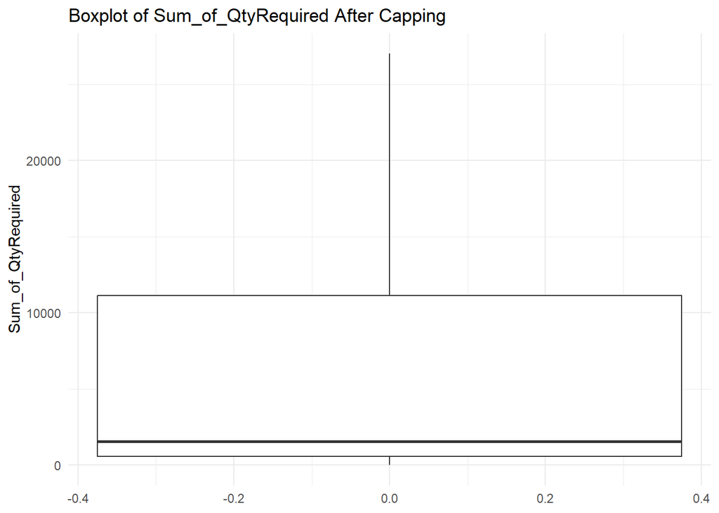

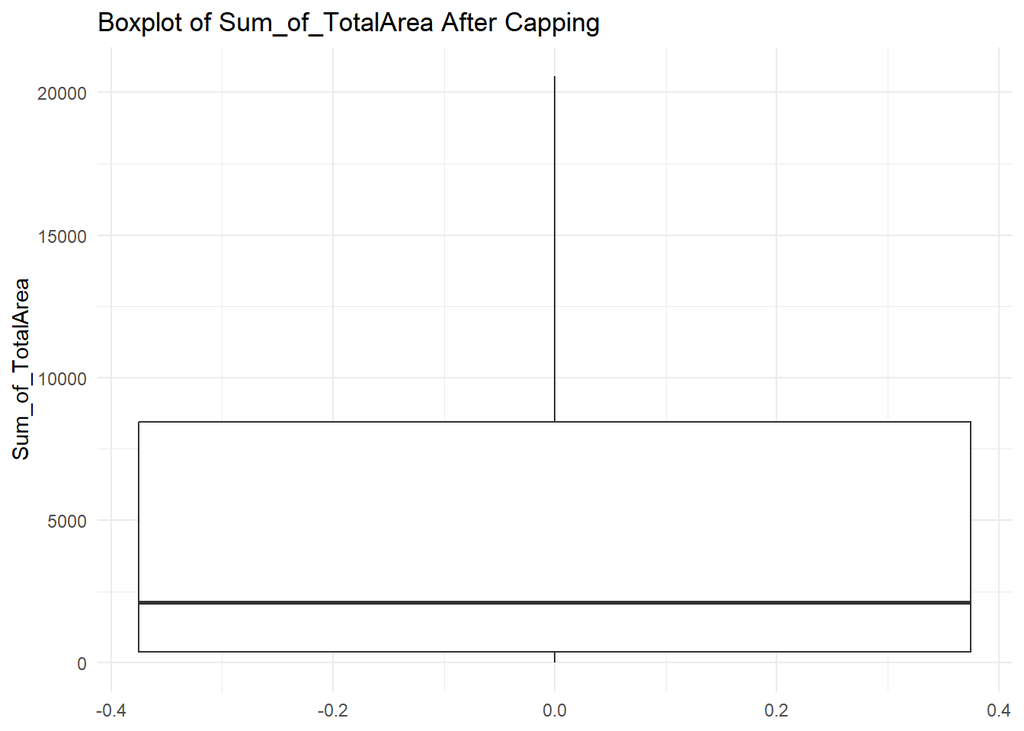

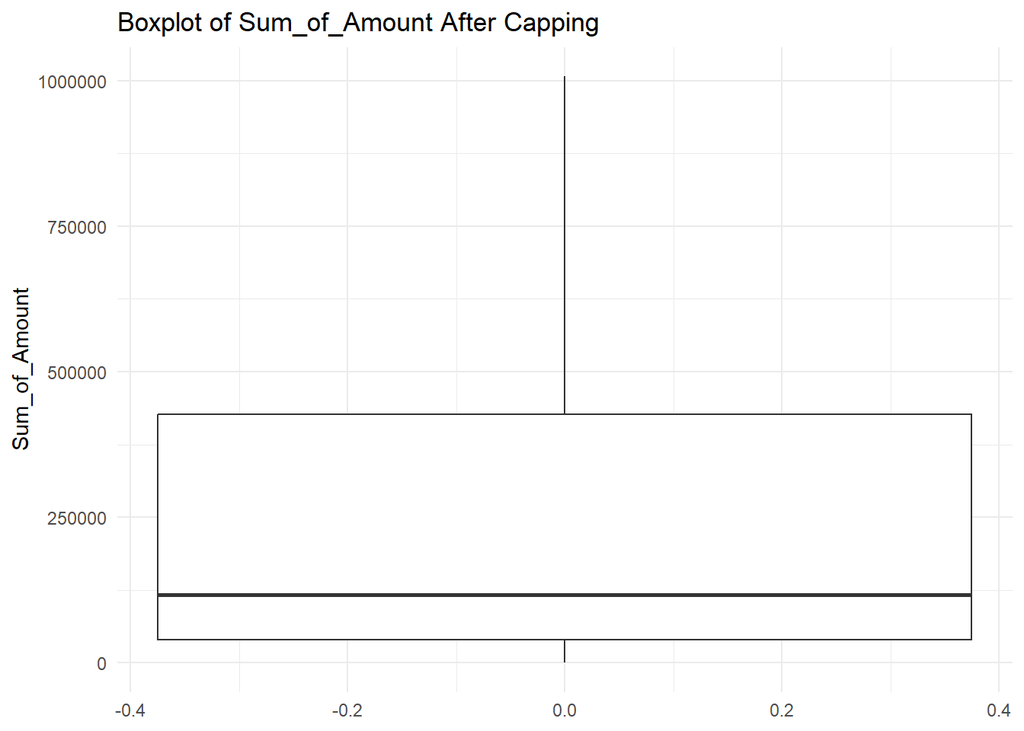

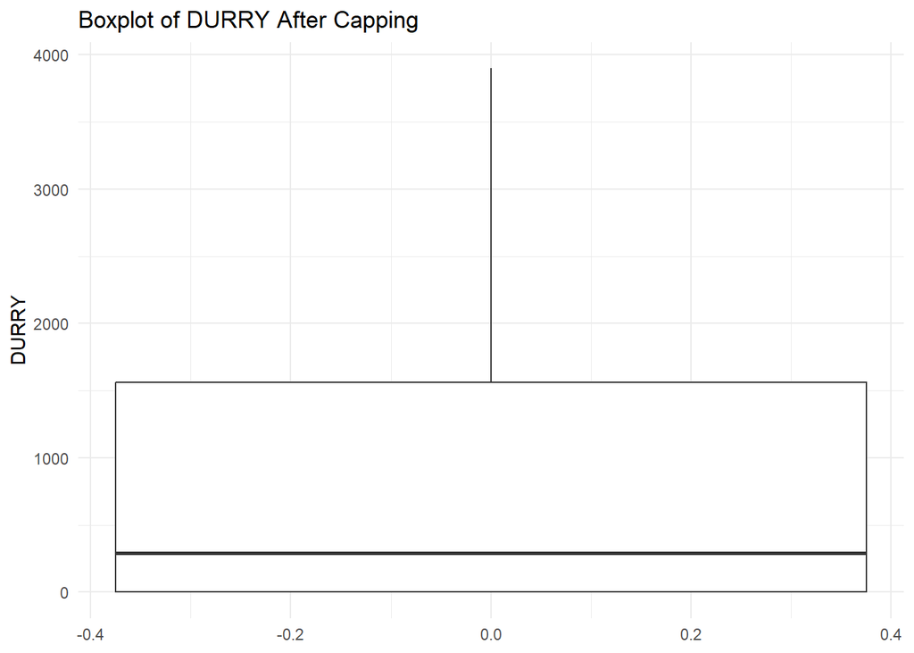

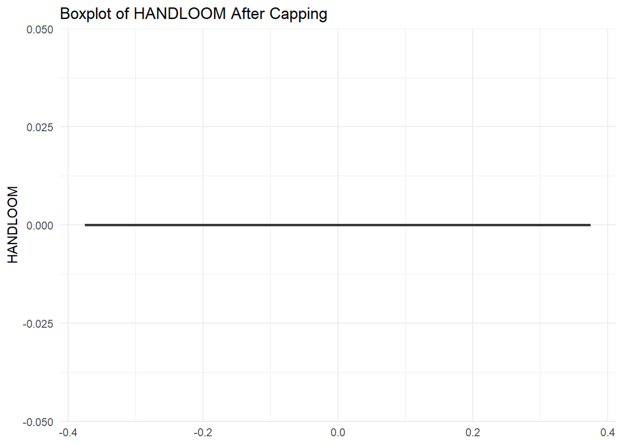

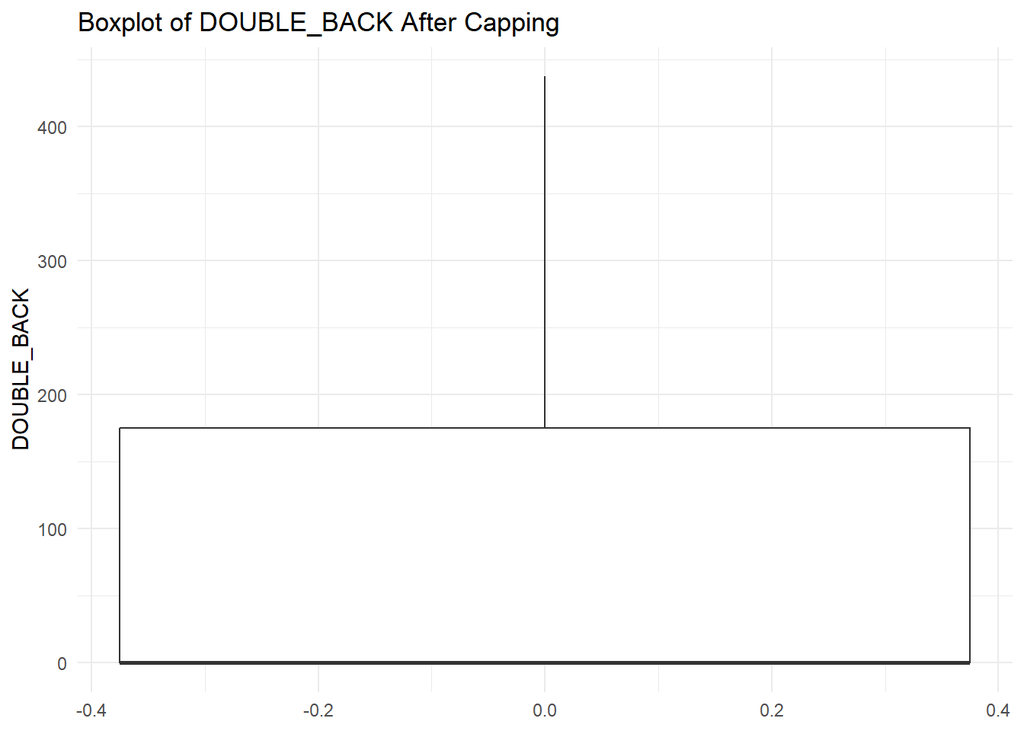

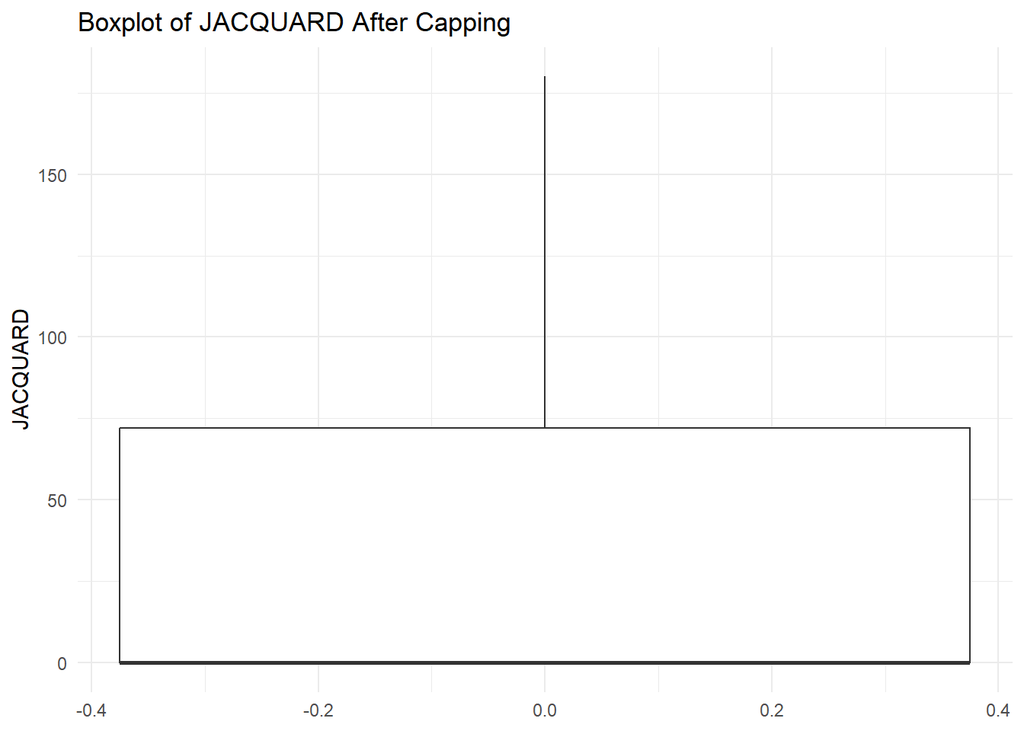

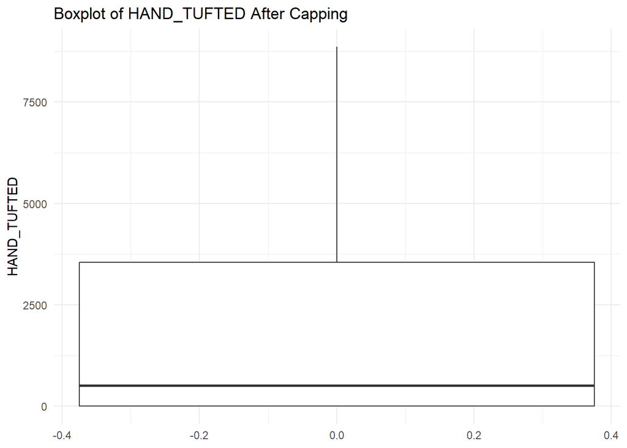

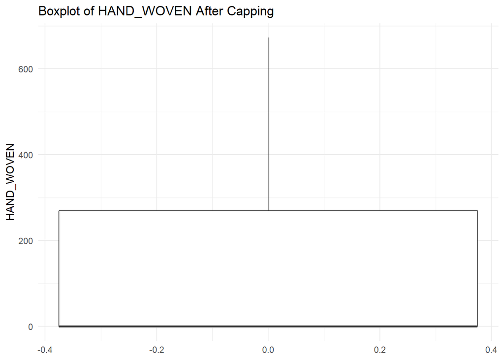

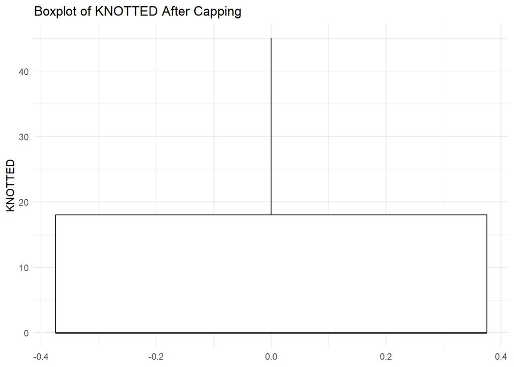

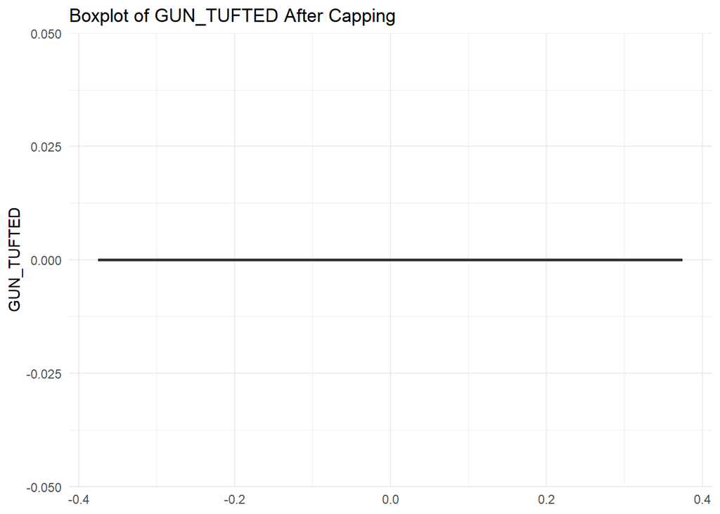

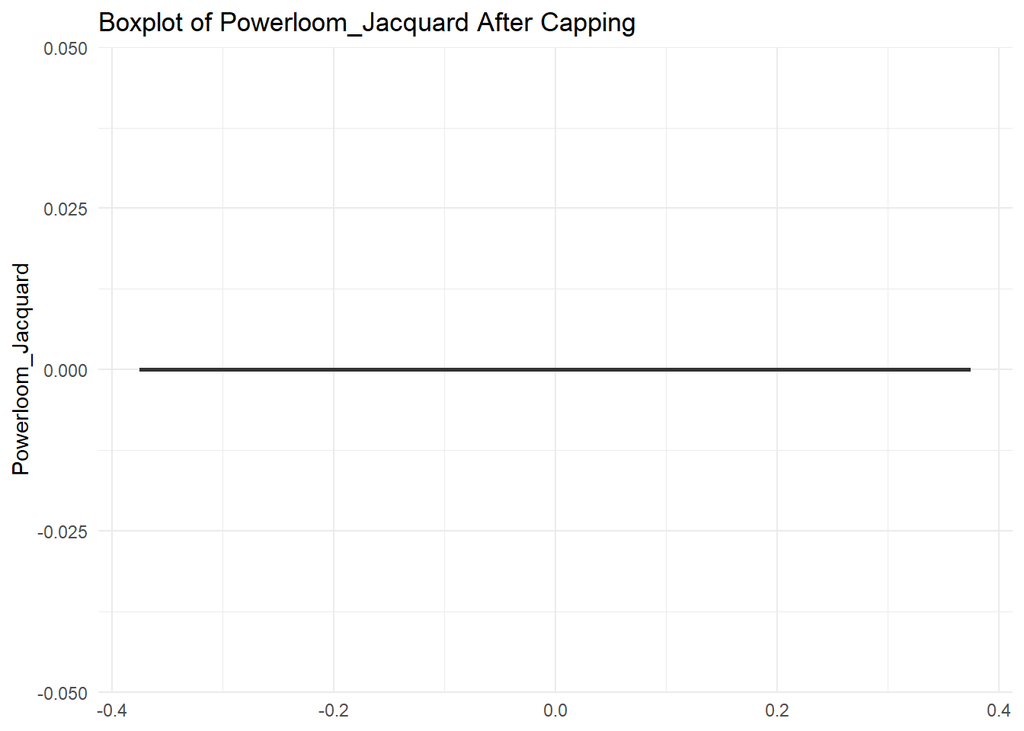

[1 more figures not shown]

```r
handle_outliers_iqr_cap <- function(datasample) {
  numeric_columns <- sapply(datasample, is.numeric)  # Identify numeric columns

  datasample[numeric_columns] <- lapply(datasample[numeric_columns], function(column) {
    if (is.numeric(column)) {
      Q1 <- quantile(column, 0.25, na.rm = TRUE)
      Q3 <- quantile(column, 0.75, na.rm = TRUE)
      IQR <- Q3 - Q1
      lower_bound <- Q1 - 1.5 * IQR
      upper_bound <- Q3 + 1.5 * IQR

      # Cap the values at lower and upper bounds
      column[column < lower_bound] <- lower_bound
      column[column > upper_bound] <- upper_bound
    }
    return(column)
  })

  return(datasample)
}

# Apply the capping method
data_capped <- handle_outliers_iqr_cap(datacluster)

library(ggplot2)

numeric_columns <- names(data_capped)[sapply(data_capped, is.numeric)]

for (column_name in numeric_columns) {
  print(
    ggplot(data_capped, aes_string(y = paste0("`", column_name, "`"))) +
      geom_boxplot(outlier.colour = "blue", outlier.shape = 16, outlier.size = 2) +
      labs(title = paste("Boxplot of", column_name, "After Capping"), y = column_name) +
      theme_minimal()
  )
}
```

>>The outliers have been successfully removed.

#Check for duplicates

```r
# Check for duplicate rows for DataCluster
duplicate_CCode <- datacluster$"Row Labels"[duplicated(datacluster$"Row Labels")]
print(duplicate_CCode)
```

[output not shown]

#Normalize High variability in scale between features can introduce noise in certain algorithms. Therefore, I decided to normalize the data using the min/max method.I implemented normalization specifically for the Datacluster and DataSample. Normalize All Numerical Variables:

```r
# Normalize numerical columns (min-max scaling)
normalize <- function(x) {
  return((x - min(x)) / (max(x) - min(x)))
}

# Apply normalization only to numeric columns

numeric_columns <- sapply(datacluster, is.numeric)
datacluster[numeric_columns] <- lapply(datacluster[numeric_columns], normalize)

str(datacluster)
```

```
## tibble [45 × 14] (S3: tbl_df/tbl/data.frame)
##  $ Row_Labels        : chr [1:45] "A-11" "A-6" "A-9" "B-2" ...
##  $ Sum_of_QtyRequired: num [1:45] 0.013449 0.000704 0.103278 0.003395 0.002522 ...
##  $ Sum_of_TotalArea  : num [1:45] 0.000659 0.00994 0.25569 0.000961 0.040292 ...
##  $ Sum_of_Amount     : num [1:45] 0.01632 0.000522 0.140357 0.001277 0.005141 ...
##  $ DURRY             : num [1:45] 0.00731 0 0.02568 0.00416 0 ...
##  $ HANDLOOM          : num [1:45] 0.393 0 0 0 0 ...
##  $ DOUBLE_BACK       : num [1:45] 0 0.0046 0.0322 0 0.0844 ...
##  $ JACQUARD          : num [1:45] 0 0.1485 1 0.0028 0.007 ...
##  $ HAND_TUFTED       : num [1:45] 0 0 0.193 0 0 ...
##  $ HAND_WOVEN        : num [1:45] 0 0 0.14783 0.00286 0 ...
##  $ KNOTTED           : num [1:45] 0 0 0.0649 0 0 ...
##  $ GUN_TUFTED        : num [1:45] 0 0 0 0 0 ...
##  $ Powerloom_Jacquard: num [1:45] 0 0 0 0 0 0 0 0 0 0 ...
##  $ INDO_TEBETAN      : num [1:45] 0 0 0 0 0 0 0 0 0 0 ...
```

```r
# Apply normalization only to numeric columns

numeric_columns <- sapply(datasample, is.numeric)
datasample[numeric_columns] <- lapply(datasample[numeric_columns], normalize)
```

#Correlation Matrix dentify highly correlated numerical features

```r
#  Filter out numeric columns
numeric_datasample <- datasample[sapply(datasample, is.numeric)]

#  Calculate the correlation matrix for numeric columns
correlation_matrix <- cor(numeric_datasample)

# View the correlation matrix
print("Correlation Matrix:")
```

```
## [1] "Correlation Matrix:"
```

```r
print(correlation_matrix)
```

```
##                      USA           UK        Italy      Belgium      Romania
## USA          1.000000000 -0.109874046 -0.051013843 -0.088041520 -0.033935356
## UK          -0.109874046  1.000000000 -0.016897033 -0.029161506 -0.011240220
## Italy       -0.051013843 -0.016897033  1.000000000 -0.013539507 -0.005218765
## Belgium     -0.088041520 -0.029161506 -0.013539507  1.000000000 -0.009006732
## Romania     -0.033935356 -0.011240220 -0.005218765 -0.009006732  1.000000000
## Australia    0.072275002 -0.007941147 -0.003687026 -0.006363201 -0.002452678
## India       -0.842908938 -0.279192064 -0.129627156 -0.223715196 -0.086230393
## QtyRequired  0.099819146 -0.013928910 -0.011393876  0.048935665 -0.001321345
## Hand_Tufted  0.232515880  0.002348261  0.036755363 -0.129433964  0.027769114
## Durry       -0.155575256  0.003259090 -0.035864121  0.087781747 -0.035678105
## Double_Back -0.049075178 -0.001003362 -0.028720412 -0.049566718 -0.009064621
## Hand_Woven  -0.070415376  0.006444130  0.027140925  0.162446595 -0.021958356
## Knotted      0.008305734  0.011767282 -0.017491941 -0.030188218 -0.011635964
## Jacquard    -0.010292128  0.010983561 -0.010223054 -0.017643313 -0.006800566
## Handloom     0.006414015 -0.018102437 -0.011751391 -0.011398829  0.127757218
## Other       -0.056782731 -0.033003947  0.019829377 -0.026445897 -0.010193497
## REC         -0.035559263 -0.042301004 -0.040435544  0.017992898 -0.018440029
## Round        0.011341518  0.057051492 -0.008838718 -0.015254177  0.023936486
## Square       0.048849328 -0.011790889  0.090427751 -0.009447980 -0.003641697
## AreaFt      -0.009093728  0.005146439  0.035274895 -0.006014880 -0.029230021
##                Australia        India   QtyRequired  Hand_Tufted         Durry
## USA          0.072275002 -0.842908938  0.0998191464  0.232515880 -0.1555752560
## UK          -0.007941147 -0.279192064 -0.0139289096  0.002348261  0.0032590896
## Italy       -0.003687026 -0.129627156 -0.0113938759  0.036755363 -0.0358641214
## Belgium     -0.006363201 -0.223715196  0.0489356653 -0.129433964  0.0877817465
## Romania     -0.002452678 -0.086230393 -0.0013213450  0.027769114 -0.0356781047
## Australia    1.000000000 -0.060921245 -0.0056793108 -0.009924338 -0.0252063625
## India       -0.060921245  1.000000000 -0.1005501441 -0.185739170  0.1262724196
## QtyRequired -0.005679311 -0.100550144  1.0000000000  0.011839881 -0.0099057772
## Hand_Tufted -0.009924338 -0.185739170  0.0118398810  1.000000000 -0.5127229884
## Durry       -0.025206363  0.126272420 -0.0099057772 -0.512722988  1.0000000000
## Double_Back -0.013497814  0.068416806  0.0182178913 -0.274559237 -0.1963471944
## Hand_Woven  -0.015513444  0.008386761 -0.0282225293 -0.315559186 -0.2256677335
## Knotted      0.101281756  0.002085885 -0.0024255279 -0.167218137 -0.1195837096
## Jacquard     0.068287941  0.013659267  0.0009809766 -0.097729583 -0.0698899431
## Handloom    -0.005522835 -0.009033507  0.0470565102 -0.112340067 -0.0803384263
## Other       -0.007201643  0.071786692 -0.0199189327 -0.146488723 -0.1047593596
## REC          0.004899755  0.053914665 -0.0046384371 -0.024204958  0.0006561541
## Round       -0.004153958 -0.029532834  0.0102136869  0.004253709  0.0146487099
```

[output cut: 29 more lines]

```
## Australia   -0.007201643  0.0048997554 -0.004153958 -0.002572837 -0.002135875
## India        0.071786692  0.0539146646 -0.029532834 -0.054267516  0.005367573
## QtyRequired -0.019918933 -0.0046384371  0.010213687 -0.007644134 -0.001998995
## Hand_Tufted -0.146488723 -0.0242049575  0.004253709  0.038814041  0.165695691
## Durry       -0.104759360  0.0006561541  0.014648710 -0.024744469 -0.155817995
## Double_Back -0.056097835  0.0330889689 -0.032357622 -0.010466218 -0.022017793
## Hand_Woven  -0.064474929  0.0347600933 -0.026489426 -0.023034116 -0.051028610
## Knotted     -0.034165944  0.0232453583 -0.019707155 -0.012206021  0.043725311
## Jacquard    -0.019968070  0.0135856027 -0.011517722 -0.007133732  0.053527779
## Handloom    -0.022953278  0.0156166380 -0.013239611 -0.008200218  0.037886762
## Other        1.000000000 -0.1038162929  0.097381168  0.039482091 -0.052777010
## REC         -0.103816293  1.0000000000 -0.847788802 -0.525094975  0.044265012
## Round        0.097381168 -0.8477888025  1.000000000 -0.006167731 -0.045959941
## Square       0.039482091 -0.5250949747 -0.006167731  1.000000000 -0.009711342
## AreaFt      -0.052777010  0.0442650117 -0.045959941 -0.009711342  1.000000000
```

```r
# Identify highly correlated features
threshold <- 0.6  # Define the correlation threshold
highly_correlated <- which(abs(correlation_matrix) > threshold & abs(correlation_matrix) < 1, arr.ind = TRUE)

#Create a data frame of highly correlated pairs
highly_correlated_pairs <- data.frame(
  Feature1 = rownames(correlation_matrix)[highly_correlated[, 1]],
  Feature2 = colnames(correlation_matrix)[highly_correlated[, 2]],
  Correlation = correlation_matrix[highly_correlated]
)

print("Highly Correlated Feature Pairs:")
```

```
## [1] "Highly Correlated Feature Pairs:"
```

```r
print(highly_correlated_pairs)
```

```
##   Feature1 Feature2 Correlation
## 1    India      USA  -0.8429089
## 2      USA    India  -0.8429089
## 3    Round      REC  -0.8477888
## 4      REC    Round  -0.8477888
```

##EDA part

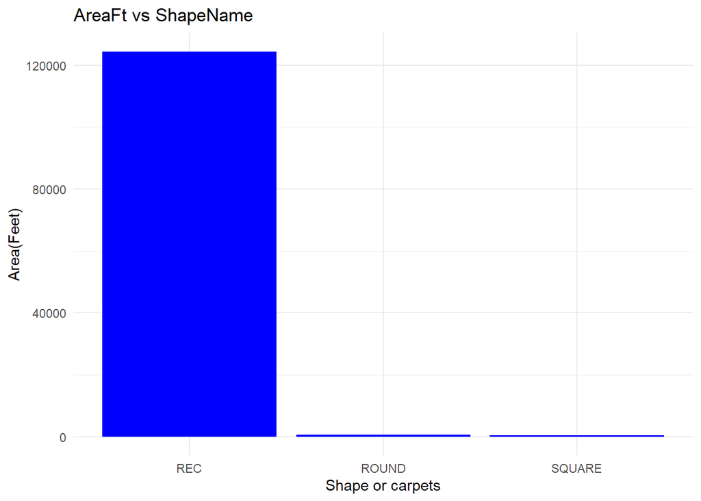

```r
ggplot(datasample_org, aes(x = ShapeName, y = AreaFt)) +
  geom_bar(stat = "identity", fill = "blue") +
  labs(title = "AreaFt vs ShapeName", x = "Shape or carpets", y = "Area(Feet)") +
  theme_minimal()
```

The bar chart illustrates the relationship between ShapeName (categories: REC, ROUND, SQUARE) and AreaFt, showing that the rectangular shape (REC) has a significantly larger total area compared to ROUND and SQUARE, which have much smaller and similar areas. This indicates that rectangular shapes carpets in terms of total area, possibly due to higher usage. In contrast, ROUND and SQUARE shapes carpets occupy considerably less area, suggesting they are less prevalent or required in the dataset’s context. This distribution highlights the importance of rectangular shapes in the given scenario.

Bar Chart: AreaFt (X) vs ITEM_NAME (Y)

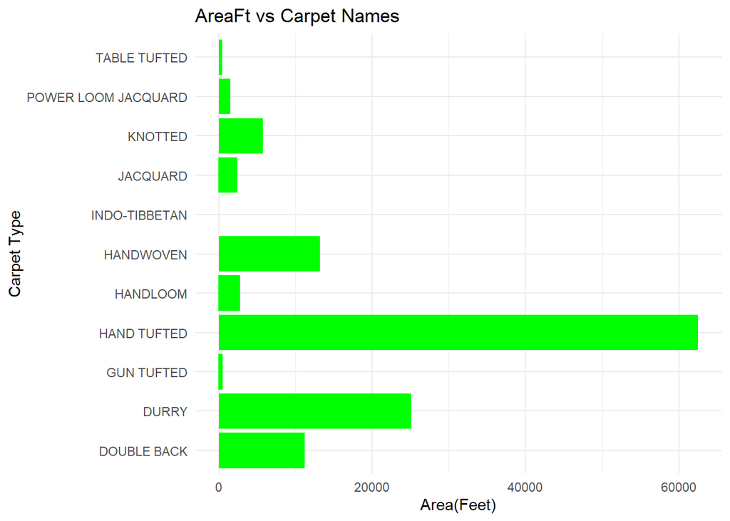

```r
ggplot(datasample_org, aes(x = AreaFt, y = ITEM_NAME)) +
  geom_bar(stat = "identity", fill = "green") +
  labs(title = "AreaFt vs Carpet Names ", x = "Area(Feet)", y = "Carpet Type") +
  theme_minimal()
```

The bar chart depicts the total `AreaFt` (in square feet) for various carpet types, with `Carpet Type` on the Y-axis and `AreaFt` on the X-axis. Among the carpet types, `HAND TUFTED` dominates, accounting for the largest area, significantly outpacing all others. `DURRY` and `HANDWOVEN` also contribute notably but are far behind `HAND TUFTED`. In contrast, carpet types like `TABLE TUFTED`, `POWER LOOM JACQUARD`, and `GUN TUFTED` occupy minimal areas, indicating their lower prevalence or usage. This distribution suggests that `HAND TUFTED` carpets are a primary focus or in highest demand within the dataset, while other types play a much smaller role in terms of area covered.

Bar Chart: AreaFt (X) vs CountryName (Y)

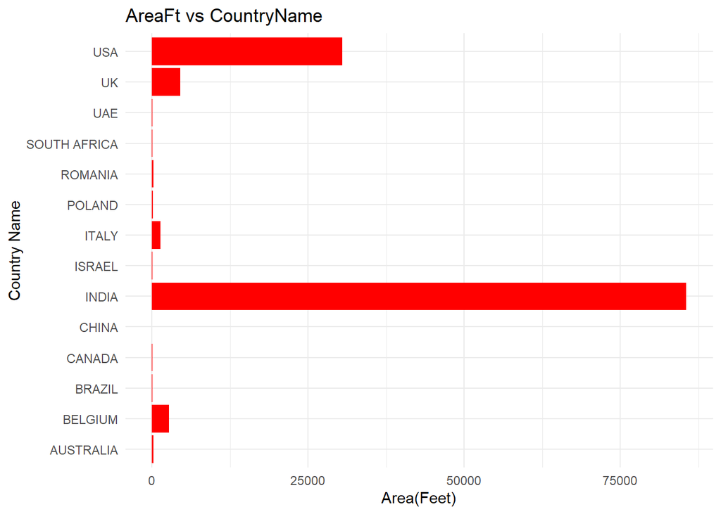

```r
ggplot(datasample_org, aes(x = AreaFt, y = CountryName)) +
  geom_bar(stat = "identity", fill = "red") +
  labs(title = "AreaFt vs CountryName", x = "Area(Feet)", y = "Country Name") +
  theme_minimal()
```

Bar Chart: AreaFt (X) vs CustomerCode (Y)

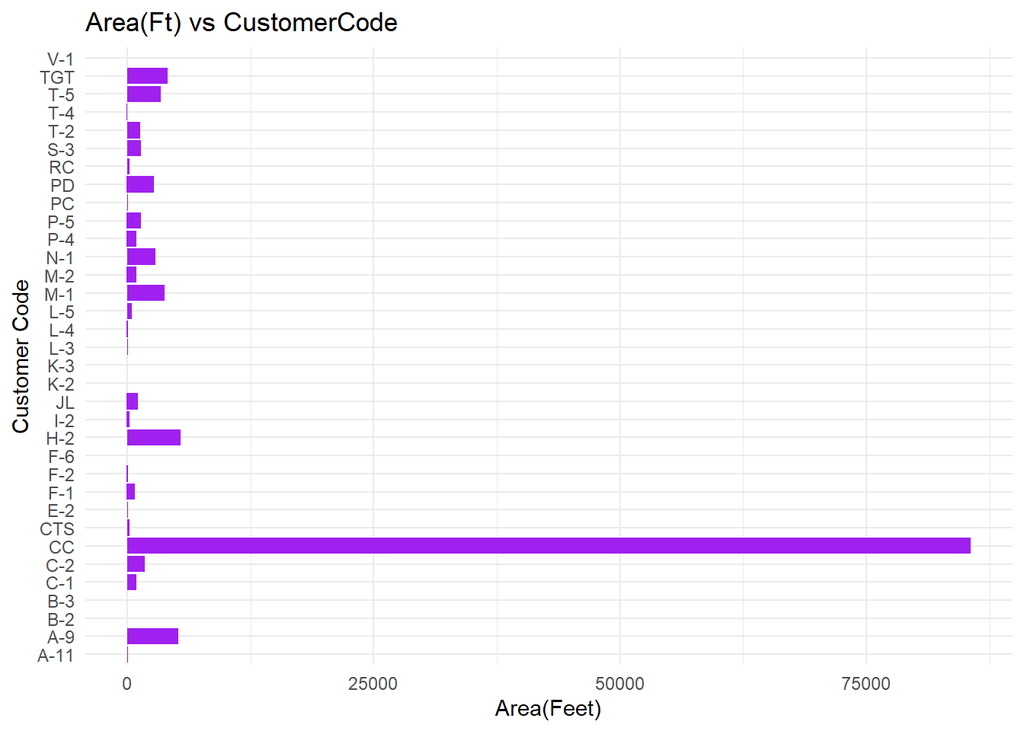

```r
ggplot(datasample_org, aes(x = AreaFt, y = CustomerCode)) +
  geom_bar(stat = "identity", fill = "purple") +
  labs(title = "Area(Ft) vs CustomerCode", x = "Area(Feet)", y = "Customer Code") +
  theme_minimal()
```

“Order Conversion” distriburion

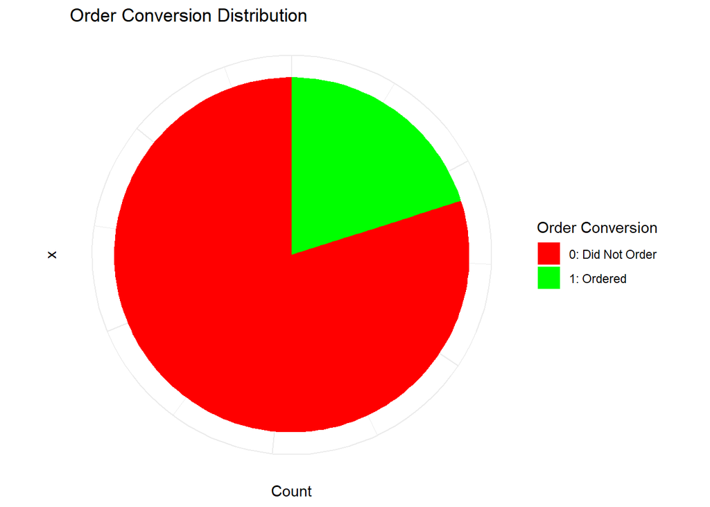

```r
# Count the values in the "Order Conversion" column
order_conversion_counts <- table(datasample_org$`Order Conversion`)

# Convert the table to a data frame for visualization
order_conversion_df <- as.data.frame(order_conversion_counts)
colnames(order_conversion_df) <- c("OrderConversion", "Count")

# Load ggplot2 for visualization
library(ggplot2)

# Create the pie chart
ggplot(order_conversion_df, aes(x = "", y = Count, fill = factor(OrderConversion))) +
  geom_bar(stat = "identity", width = 1) +
  coord_polar(theta = "y") +  # Convert to a pie chart
  scale_fill_manual(values = c("red", "green"), labels = c("0: Did Not Order", "1: Ordered")) +
  labs(
    title = "Order Conversion Distribution",
    fill = "Order Conversion"
  ) +
  theme_minimal() +
  theme(axis.text.x = element_blank())  # Remove x-axis labels for cleaner pie chart
```

The pie chart represents the distribution of `Order Conversion`, highlighting the proportion of customers who placed an order after receiving a sample (`1: Ordered`) versus those who did not (`0: Did Not Order`). The red segment, representing customers who did not order, occupies the majority of the chart, indicating that most customers did not convert to placing an order. The green segment, representing customers who placed an order, is comparatively smaller, showing that a smaller proportion of customers successfully converted. This visualization emphasizes the disparity between the two groups, suggesting a potential area for improvement in conversion strategies.

#EDA od the datacluster dataset “Sum of QtyRequired”, “Sum of TotalArea” and “Sum of Amount” in “Row Labels” that shows the behiviar of different group of costumers in the terms ofNumber of units ordered , Carpet area and carpet (in USD)

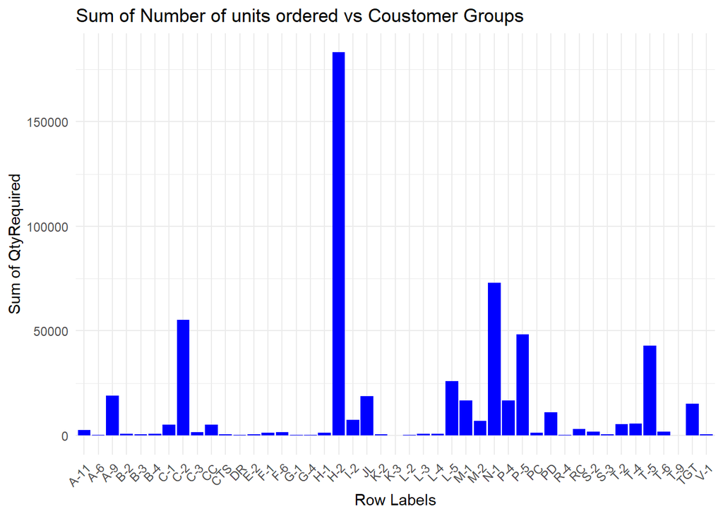

```r
# Bar chart for "Sum of QtyRequired"
ggplot(datacluster_org, aes(x = `Row Labels`, y = `Sum of QtyRequired`)) +
  geom_bar(stat = "identity", fill = "blue") +
  labs(
    title = "Sum of Number of units ordered vs Coustomer Groups",
    x = "Row Labels",
    y = "Sum of QtyRequired"
  ) +
  theme_minimal() +
  theme(axis.text.x = element_text(angle = 45, hjust = 1))  # Rotate X-axis labels if needed
```

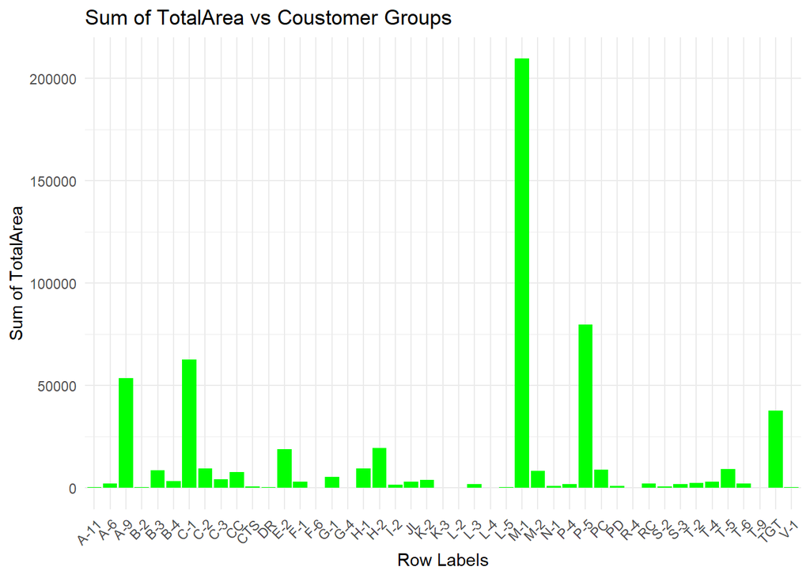

```r
# Bar chart for "Sum of TotalArea"
ggplot(datacluster_org, aes(x = `Row Labels`, y = `Sum of TotalArea`)) +
  geom_bar(stat = "identity", fill = "green") +
  labs(
    title = "Sum of TotalArea vs Coustomer Groups",
    x = "Row Labels",
    y = "Sum of TotalArea"
  ) +
  theme_minimal() +
  theme(axis.text.x = element_text(angle = 45, hjust = 1))
```

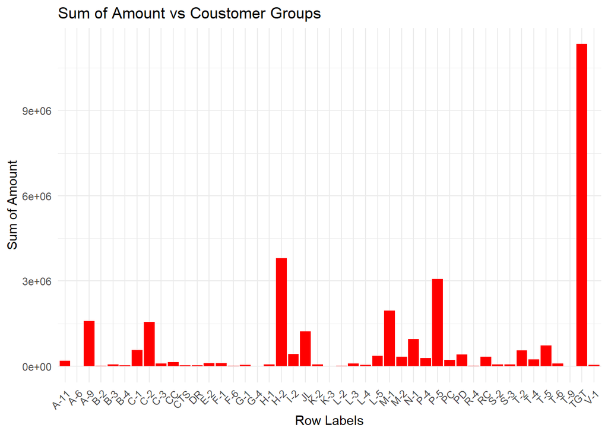

```r
# Bar chart for "Sum of Amount"
ggplot(datacluster_org, aes(x = `Row Labels`, y = `Sum of Amount`)) +
  geom_bar(stat = "identity", fill = "red") +
  labs(
    title = "Sum of Amount vs Coustomer Groups",
    x = "Row Labels",
    y = "Sum of Amount"
  ) +
  theme_minimal() +
  theme(axis.text.x = element_text(angle = 45, hjust = 1))
```

##Model Imputation

#predivtive model on Sample Data

```r
datasample <- datasample[, !(names(datasample) %in% c("India", "OtherCountries", "Other","CustomerCode"))]

set.seed(123)  # For reproducibility
train_index <- sample(1:nrow(datasample), 0.8 * nrow(datasample))  # Randomly select 80% of the rows
train_data <- datasample[train_index, ]  # Training set (80% of the data)
test_data <- datasample[-train_index, ]  # Testing set (remaining 20% of the data)
```

##Train a Predictive Model:

#Train Logistic Regression

```r
logistic_model <- glm(Order_Conversion ~ ., data = train_data, family = binomial)

# Predictions
logistic_probs <- predict(logistic_model, test_data, type = "response")
logistic_classes <- ifelse(logistic_probs > 0.5, 1, 0)
```

#Train Decision Tree

```r
decision_tree_model <- rpart(Order_Conversion ~ ., data = train_data, method = "class")

# Predictions
decision_tree_probs <- predict(decision_tree_model, test_data, type = "prob")[, 2]
decision_tree_classes <- predict(decision_tree_model, test_data, type = "class")
```

#Train Random Forest

```r
random_forest_model <- randomForest(Order_Conversion ~ ., data = train_data, ntree = 100)

# Predictions
random_forest_probs <- predict(random_forest_model, test_data, type = "prob")[, 2]
random_forest_classes <- predict(random_forest_model, test_data)
```

# Train K-Nearest Neighbors (KNN)

```r
knn_model <- train(Order_Conversion ~ ., data = train_data, method = "kknn", tuneLength = 5)

# Predictions
knn_probs <- predict(knn_model, test_data, type = "prob")[, 2]
knn_classes <- predict(knn_model, test_data)
```

#Evaluation Metrics

```r
evaluate_model <- function(actual, predicted, probs) {
  cm <- confusionMatrix(as.factor(predicted), as.factor(actual), positive = "1")

  # Calculate metrics
  accuracy <- cm$overall["Accuracy"]
  precision <- cm$byClass["Pos Pred Value"]
  recall <- cm$byClass["Sensitivity"]
  f1 <- 2 * (precision * recall) / (precision + recall)
  false_alarm <- cm$byClass["Specificity"]

  return(c(Accuracy = accuracy, Precision = precision, Recall = recall, F1 = f1, False_Alarm = 1 - false_alarm))
}
```

#Confusion Matrices for Each Model

```r
# Logistic Regression
logistic_cm <- confusionMatrix(as.factor(logistic_classes), as.factor(test_data$Order_Conversion), positive = "1")
print("Confusion Matrix - Logistic Regression")
```

```
## [1] "Confusion Matrix - Logistic Regression"
```

```r
print(logistic_cm)
```

```
## Confusion Matrix and Statistics
##
##           Reference
## Prediction   0   1
##          0 896 114
##          1  40 107
##
##                Accuracy : 0.8669
##                  95% CI : (0.846, 0.886)
##     No Information Rate : 0.809
##     P-Value [Acc > NIR] : 1.062e-07
##
##                   Kappa : 0.5062
##
##  Mcnemar's Test P-Value : 4.041e-09
##
##             Sensitivity : 0.48416
##             Specificity : 0.95726
##          Pos Pred Value : 0.72789
##          Neg Pred Value : 0.88713
##              Prevalence : 0.19101
##          Detection Rate : 0.09248
##    Detection Prevalence : 0.12705
##       Balanced Accuracy : 0.72071
##
##        'Positive' Class : 1
##
```

```r
# Decision Tree
decision_tree_cm <- confusionMatrix(as.factor(decision_tree_classes), as.factor(test_data$Order_Conversion), positive = "1")
print("Confusion Matrix - Decision Tree")
```

```
## [1] "Confusion Matrix - Decision Tree"
```

```r
print(decision_tree_cm)
```

```
## Confusion Matrix and Statistics
##
##           Reference
## Prediction   0   1
##          0 906 115
##          1  30 106
##
##                Accuracy : 0.8747
##                  95% CI : (0.8542, 0.8932)
##     No Information Rate : 0.809
##     P-Value [Acc > NIR] : 1.490e-09
##
##                   Kappa : 0.5247
##
##  Mcnemar's Test P-Value : 3.041e-12
##
##             Sensitivity : 0.47964
##             Specificity : 0.96795
##          Pos Pred Value : 0.77941
##          Neg Pred Value : 0.88737
##              Prevalence : 0.19101
##          Detection Rate : 0.09162
##    Detection Prevalence : 0.11755
##       Balanced Accuracy : 0.72379
##
##        'Positive' Class : 1
##
```

```r
# Random Forest
random_forest_cm <- confusionMatrix(as.factor(random_forest_classes), as.factor(test_data$Order_Conversion), positive = "1")
print("Confusion Matrix - Random Forest")
```

```
## [1] "Confusion Matrix - Random Forest"
```

```r
print(random_forest_cm)
```

```
## Confusion Matrix and Statistics
##
##           Reference
## Prediction   0   1
##          0 924  96
##          1  12 125
##
##                Accuracy : 0.9067
##                  95% CI : (0.8884, 0.9228)
##     No Information Rate : 0.809
##     P-Value [Acc > NIR] : < 2.2e-16
##
##                   Kappa : 0.6467
##
##  Mcnemar's Test P-Value : 1.386e-15
##
##             Sensitivity : 0.5656
##             Specificity : 0.9872
##          Pos Pred Value : 0.9124
##          Neg Pred Value : 0.9059
##              Prevalence : 0.1910
##          Detection Rate : 0.1080
##    Detection Prevalence : 0.1184
##       Balanced Accuracy : 0.7764
##
##        'Positive' Class : 1
##
```

```r
# KNN
knn_cm <- confusionMatrix(as.factor(knn_classes), as.factor(test_data$Order_Conversion), positive = "1")
print("Confusion Matrix - KNN")
```

```
## [1] "Confusion Matrix - KNN"
```

```r
print(knn_cm)
```

```
## Confusion Matrix and Statistics
##
##           Reference
## Prediction   0   1
##          0 918  69
##          1  18 152
##
##                Accuracy : 0.9248
##                  95% CI : (0.9081, 0.9393)
##     No Information Rate : 0.809
##     P-Value [Acc > NIR] : < 2.2e-16
##
##                   Kappa : 0.7332
##
##  Mcnemar's Test P-Value : 8.296e-08
##
##             Sensitivity : 0.6878
##             Specificity : 0.9808
##          Pos Pred Value : 0.8941
##          Neg Pred Value : 0.9301
##              Prevalence : 0.1910
##          Detection Rate : 0.1314
##    Detection Prevalence : 0.1469
##       Balanced Accuracy : 0.8343
##
##        'Positive' Class : 1
##
```

#Evaluation Metrics for Each Model

```r
logistic_metrics <- evaluate_model(test_data$Order_Conversion, logistic_classes, logistic_probs)
decision_tree_metrics <- evaluate_model(test_data$Order_Conversion, decision_tree_classes, decision_tree_probs)
random_forest_metrics <- evaluate_model(test_data$Order_Conversion, random_forest_classes, random_forest_probs)
knn_metrics <- evaluate_model(test_data$Order_Conversion, knn_classes, knn_probs)

# Combine metrics into a single table
metrics_table <- rbind(Logistic = logistic_metrics,
                       DecisionTree = decision_tree_metrics,
                       RandomForest = random_forest_metrics,
                       KNN = knn_metrics)

print(metrics_table)
```

```
##              Accuracy.Accuracy Precision.Pos Pred Value Recall.Sensitivity
## Logistic             0.8668971                0.7278912          0.4841629
## DecisionTree         0.8746759                0.7794118          0.4796380
## RandomForest         0.9066551                0.9124088          0.5656109
## KNN                  0.9248055                0.8941176          0.6877828
##              F1.Pos Pred Value False_Alarm.Specificity
## Logistic             0.5815217              0.04273504
## DecisionTree         0.5938375              0.03205128
## RandomForest         0.6983240              0.01282051
## KNN                  0.7774936              0.01923077
```

#Charts for Each Model

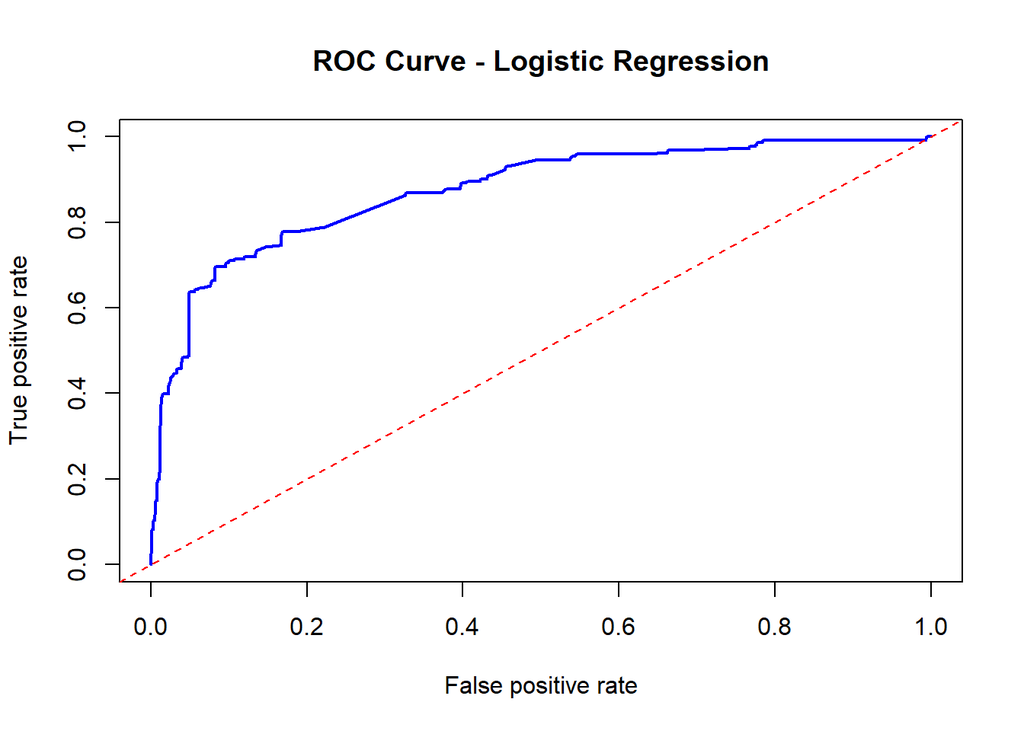

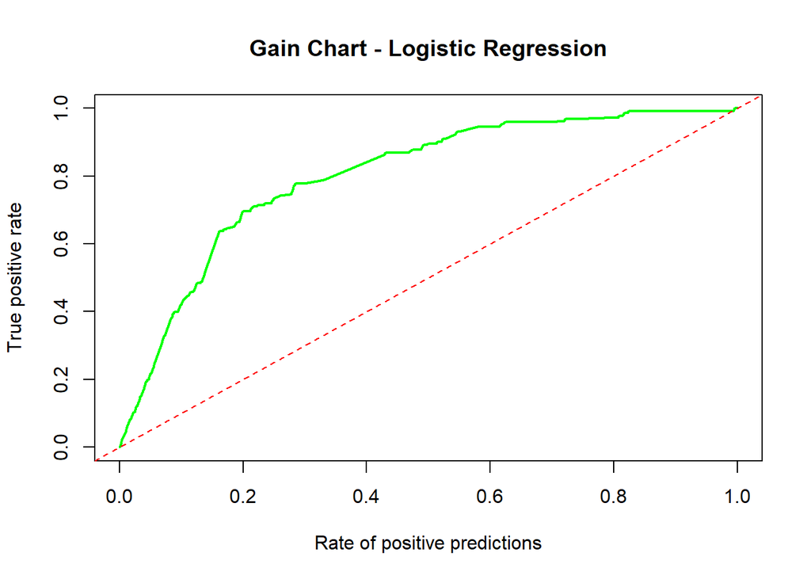

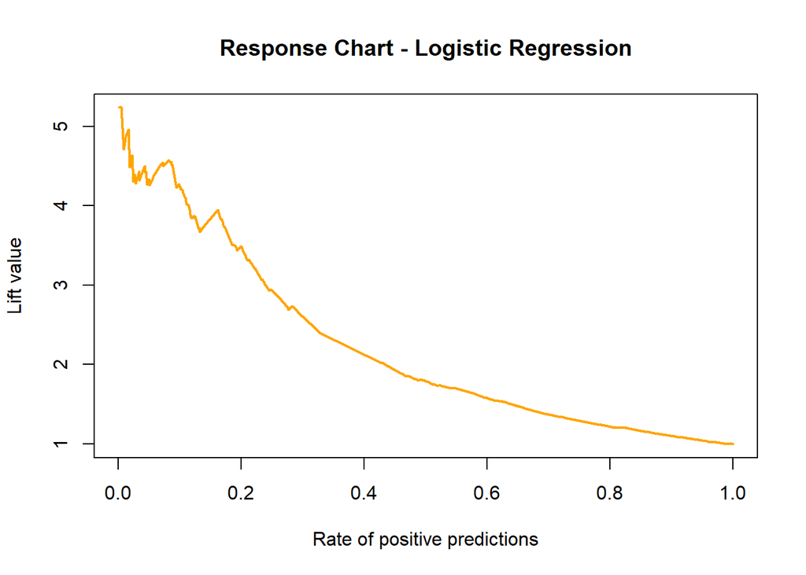

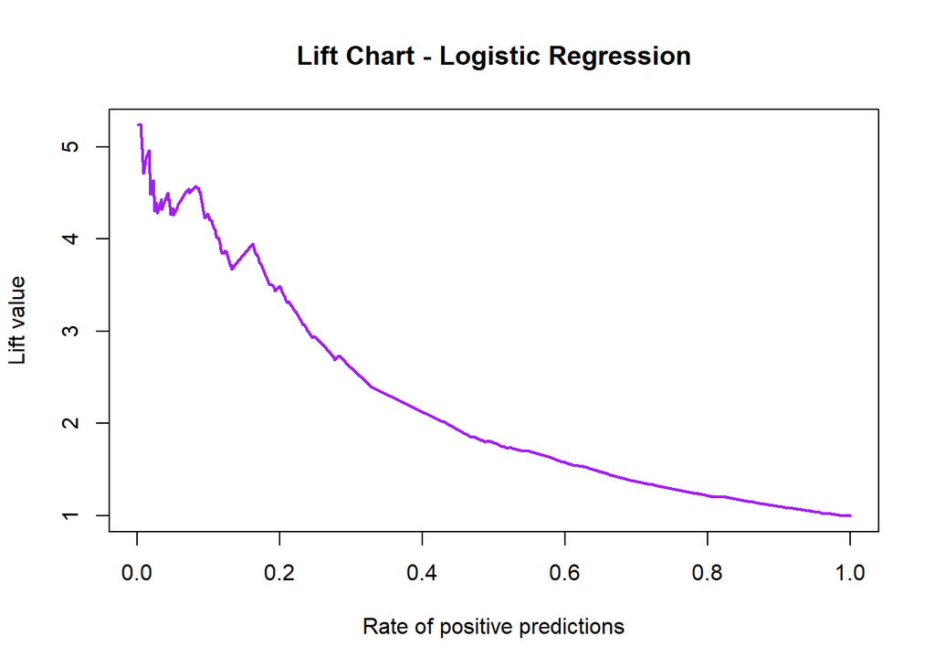

```r
plot_model_performance <- function(probs, actual, model_name) {
  pred <- prediction(probs, as.numeric(as.character(actual)))

  # ROC Curve
  perf_roc <- performance(pred, "tpr", "fpr")
  plot(perf_roc, col = "blue", lwd = 2, main = paste("ROC Curve -", model_name))
  abline(a = 0, b = 1, lty = 2, col = "red")

  # Gain Chart
  perf_gain <- performance(pred, "tpr", "rpp")
  plot(perf_gain, col = "green", lwd = 2, main = paste("Gain Chart -", model_name))
  abline(a = 0, b = 1, lty = 2, col = "red")

  # Response Chart
  perf_response <- performance(pred, "lift", "rpp")
  plot(perf_response, col = "orange", lwd = 2, main = paste("Response Chart -", model_name))

  # Lift Chart
  perf_lift <- performance(pred, "lift", "rpp")
  plot(perf_lift, col = "purple", lwd = 2, main = paste("Lift Chart -", model_name))
}

# Logistic Regression
plot_model_performance(logistic_probs, test_data$Order_Conversion, "Logistic Regression")
```

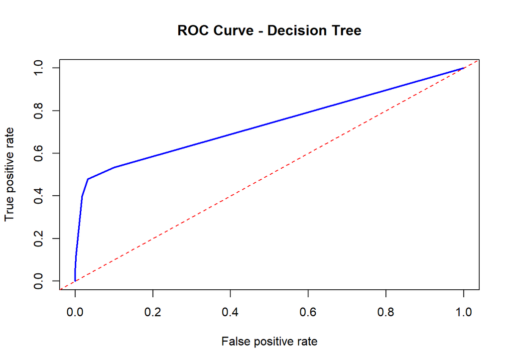

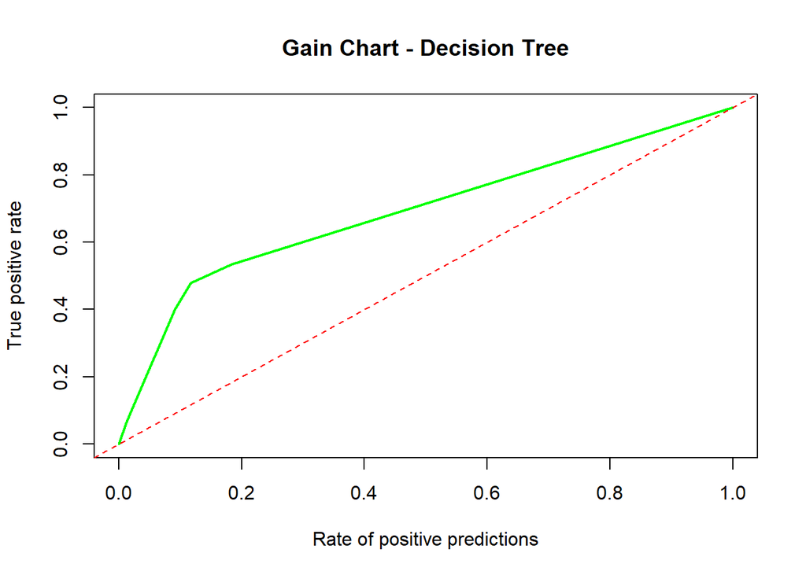

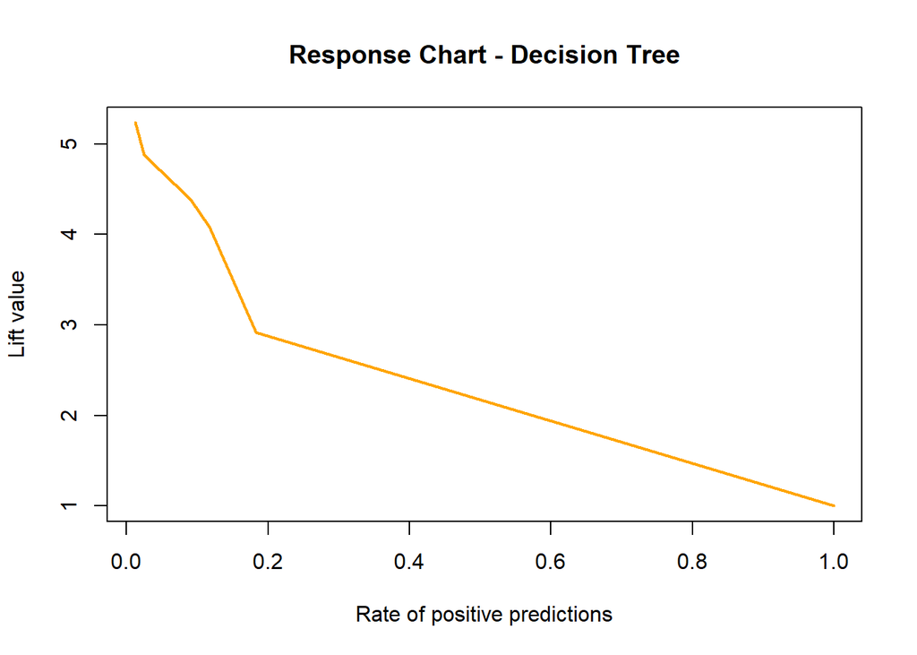

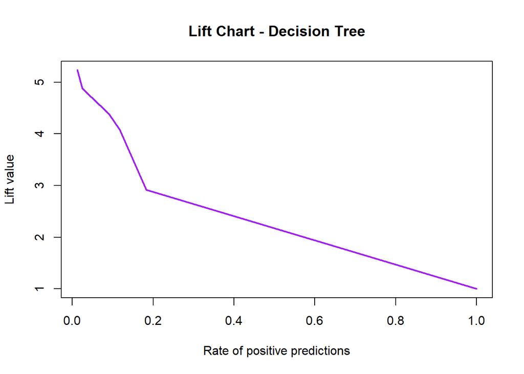

```r
# Decision Tree
plot_model_performance(decision_tree_probs, test_data$Order_Conversion, "Decision Tree")
```

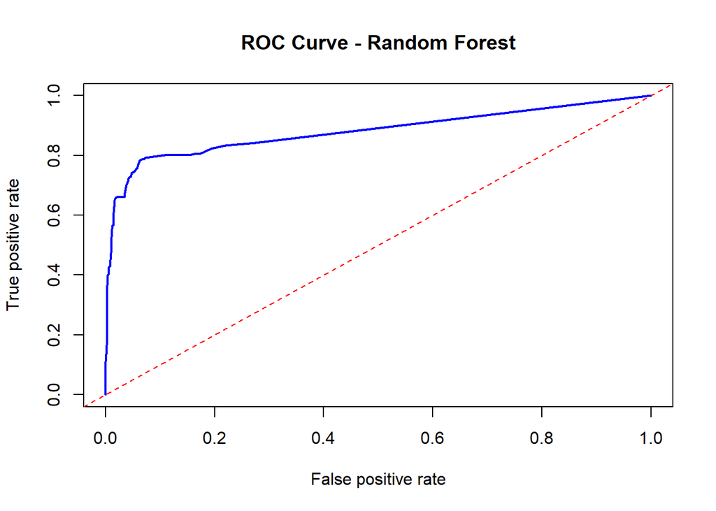

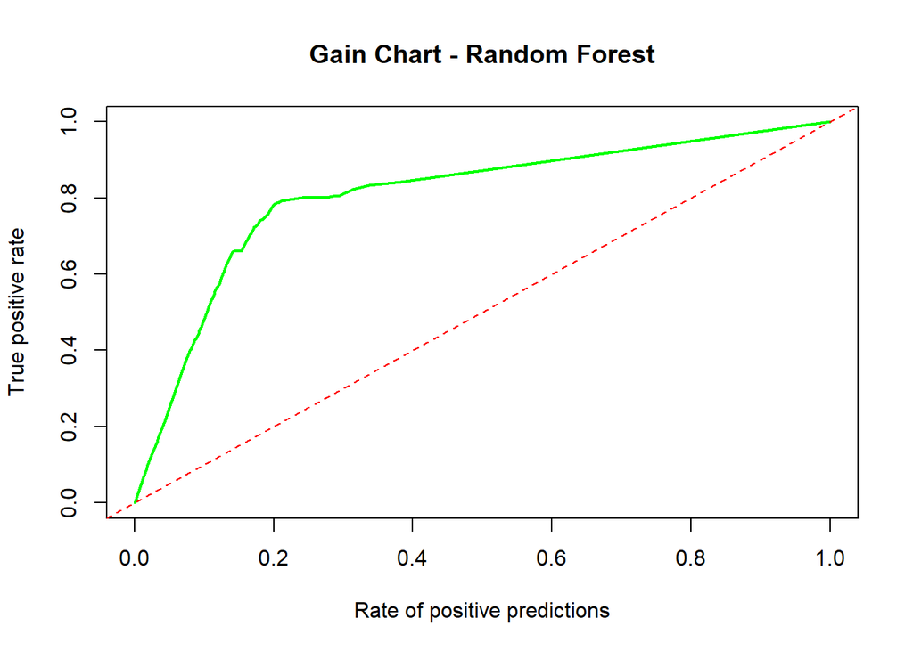

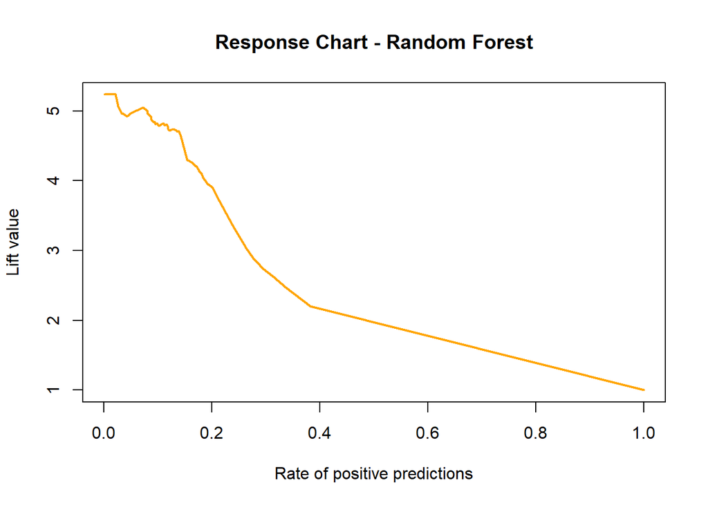

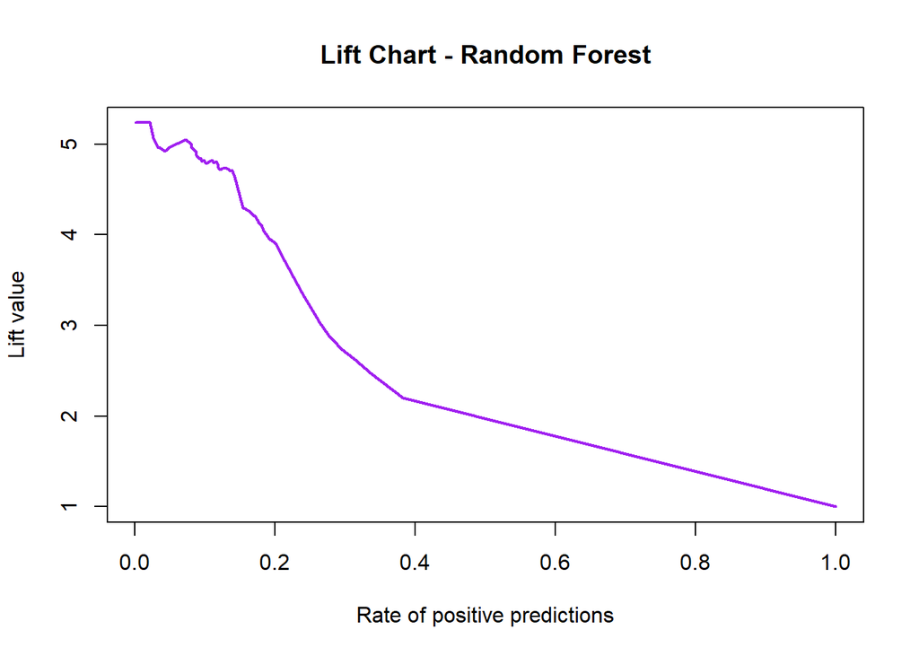

```r
# Random Forest
plot_model_performance(random_forest_probs, test_data$Order_Conversion, "Random Forest")
```